# HW3tree

Randall Thompson

3/23/2021

```r
library(tidyverse)
library(tidymodels)
cla = read_csv("cla.csv")
```

```r
cla$Loan_Amount_Term = factor(cla$Loan_Amount_Term)
cla$Loan_Status = factor(cla$Loan_Status)  # Convert the response to factor
cla$Credit_History = factor(cla$Credit_History)
cla$Property_Area = factor( cla$Property_Area)
cla$Gender = factor( cla$Gender)
cla$Married = factor(cla$Married)
cla$Dependents = ordered(cla$Dependents, levels = c("0" , "1", "2" , "3+") )
cla$Education = factor(cla$Education)
cla$Self_Employed = factor( cla$Self_Employed)
```

After we convert our text variables to factors, let’s take a look at the shape and completeness of our data.

```r
skimr::skim(cla)
```

Data summary

| Name | cla |
| --- | --- |
| Number of rows | 480 |
| Number of columns | 17 |
| _______________________ |  |
| Column type frequency: |  |
| factor | 9 |
| numeric | 8 |
| ________________________ |  |
| Group variables | None |

**Variable type: factor**

| skim_variable | n_missing | complete_rate | ordered | n_unique | top_counts |
| --- | --- | --- | --- | --- | --- |
| Gender | 0 | 1 | FALSE | 2 | Mal: 394, Fem: 86 |
| Married | 0 | 1 | FALSE | 2 | Yes: 311, No: 169 |
| Dependents | 0 | 1 | TRUE | 4 | 0: 274, 2: 85, 1: 80, 3+: 41 |
| Education | 0 | 1 | FALSE | 2 | Gra: 383, Not: 97 |
| Self_Employed | 0 | 1 | FALSE | 2 | No: 414, Yes: 66 |
| Loan_Amount_Term | 0 | 1 | FALSE | 9 | 360: 411, 180: 36, 480: 12, 300: 9 |
| Credit_History | 0 | 1 | FALSE | 2 | 1: 410, 0: 70 |
| Property_Area | 0 | 1 | FALSE | 3 | Sem: 191, Urb: 150, Rur: 139 |
| Loan_Status | 0 | 1 | FALSE | 2 | Y: 332, N: 148 |

**Variable type: numeric**

| skim_variable | n_missing | complete_rate | mean | sd | p0 | p25 | p50 | p75 | p100 | hist |
| --- | --- | --- | --- | --- | --- | --- | --- | --- | --- | --- |
| ApplicantIncome | 0 | 1 | 5364.23 | 5668.25 | 150.00 | 2898.75 | 3859.00 | 5852.50 | 81000.00 | ▇▁▁▁▁ |
| CoapplicantIncome | 0 | 1 | 1581.09 | 2617.69 | 0.00 | 0.00 | 1084.50 | 2253.25 | 33837.00 | ▇▁▁▁▁ |
| LoanAmount | 0 | 1 | 144.74 | 80.51 | 9.00 | 100.00 | 128.00 | 170.00 | 600.00 | ▇▇▁▁▁ |
| Total_Income | 0 | 1 | 6945.32 | 5969.95 | 1442.00 | 4148.00 | 5422.50 | 7672.50 | 81000.00 | ▇▁▁▁▁ |
| sApplicantIncome | 0 | 1 | 0.00 | 1.00 | -0.92 | -0.43 | -0.27 | 0.09 | 13.34 | ▇▁▁▁▁ |
| sCoapplicantIncome | 0 | 1 | 0.00 | 1.00 | -0.60 | -0.60 | -0.19 | 0.26 | 12.32 | ▇▁▁▁▁ |
| sTotal_Income | 0 | 1 | 0.00 | 1.00 | -0.92 | -0.47 | -0.26 | 0.12 | 12.40 | ▇▁▁▁▁ |
| sLoanAmount | 0 | 1 | 0.00 | 1.00 | -1.69 | -0.56 | -0.21 | 0.31 | 5.65 | ▇▇▁▁▁ |

Rows with missing data has been removed. Five of our independant variables have only two levels as displayed in n_unique. For our dependant variable, Loan_Status, we have twice the number of yes’s than no’s. We could downsample to have an even split of yes/no but with only, 480 rows left, we decided we didn’t want to lose any more data. The four numeric variables have been duplicated then centered to a mean of 0 and scaled to a standard deviation of 1. Since out CART algorithm uses sum of squares to select splits and since center and scaled data shouldn’t effect the relationship between variables, I’m going to stick with the original currency values.

```r
ncla <- cla[,1:13]
```

Next we explore the pairwise correlation of numeric and factor variable separately.

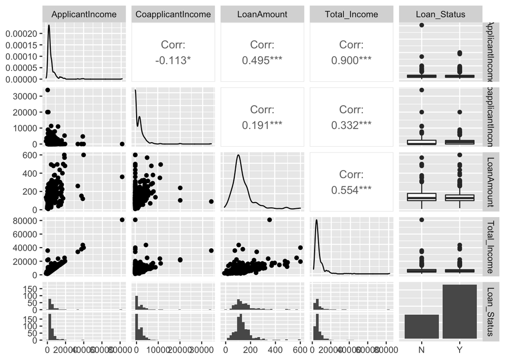

```r
GGally::ggpairs(ncla, mapping = "Loan_Status", columns = c(6:8, 13, 12)) %>% print()
```

The pairwise correlation plot shows statistical significants with three asterisks next to the correlation value. As expected, Total Income is highly correlated with applicant and coapplicant incomes since Total income is a sum of the two. More importatntly, Loan Amount is moderately positively correlated with Applicant Income and weakly positively correlated with Coapplicant Income. Overall, there doesn’t appear to be a large difference in distribution among numeric variables between a loan being approved or not.

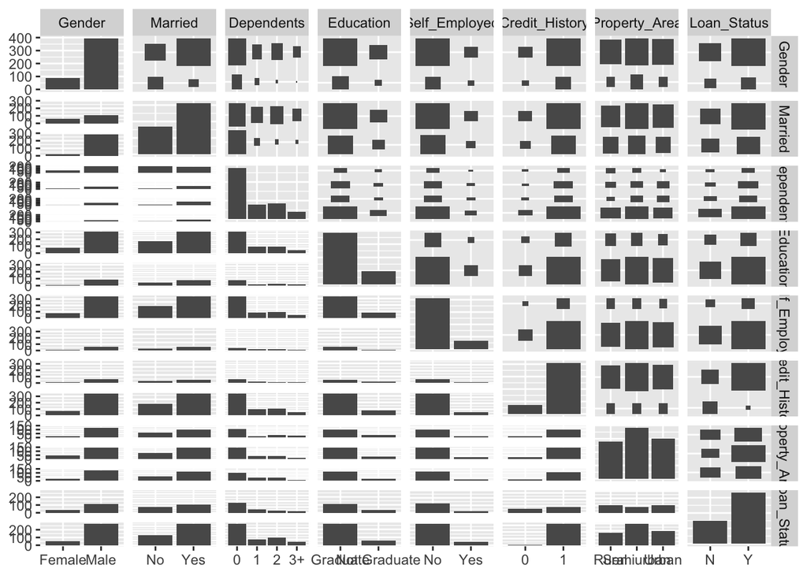

```r
GGally::ggpairs(ncla, mapping = "Loan_Status", columns = c(1:5, 10:12), ) %>% print()
```

Now we create our model recipe. This recipe object describes the dependant and independant variables we wish to use and the data source.

```r
loan_rec <- recipe(Loan_Status~., data=ncla) %>%
  prep()

loan_rec
```

```
## Data Recipe
##
## Inputs:
##
##       role #variables
##    outcome          1
##  predictor         12
##
## Training data contained 480 data points and no missing data.
```

Next we define the statistical model we wish to run on our recipe object. In this case, we are running a decision tree from the rpart package. The mode of decision tree we select is classification. Classification in the rpart package will split branches in a way that minimizes the sum of squares error.

```r
tree <- decision_tree() %>%
  set_engine("rpart") %>%
  set_mode("classification")

tree
```

```
## Decision Tree Model Specification (classification)
##
## Computational engine: rpart
```

Now we create our training and test splits using an 80/20 split. The training set will be used to train our model while the test split will be used to evaluate our final model.

```r
set.seed(1234)
loan_split <- initial_split(ncla, prop = .8)

loan_train <- training(loan_split)
loan_test <- testing(loan_split)

loan_split
```

```
## <Analysis/Assess/Total>
## <385/95/480>
```

Now we use our model engine and our training data to create a classification model.

```r
tree_fit <- tree %>% fit(Loan_Status~., data = loan_train)

tree_fit
```

```
## parsnip model object
##
## Fit time:  13ms
## n= 385
##
## node), split, n, loss, yval, (yprob)
##       * denotes terminal node
##
##  1) root 385 117 Y (0.3038961 0.6961039)
##    2) Credit_History=0 58   6 N (0.8965517 0.1034483) *
##    3) Credit_History=1 327  65 Y (0.1987768 0.8012232)
##      6) Loan_Amount_Term=36,240,300,480 16   7 N (0.5625000 0.4375000) *
##      7) Loan_Amount_Term=60,84,120,180,360 311  56 Y (0.1800643 0.8199357)
##       14) Total_Income>=18249 9   3 N (0.6666667 0.3333333) *
##       15) Total_Income< 18249 302  50 Y (0.1655629 0.8344371)
##         30) Total_Income< 2381.5 7   2 N (0.7142857 0.2857143) *
##         31) Total_Income>=2381.5 295  45 Y (0.1525424 0.8474576) *
```

No we’re going to resample our training data with 10 crossfold validation by taking a random 90% and checking the variability of our estimates.

```r
set.seed(1234)
loan_xval <- vfold_cv(data = loan_train, strata = Loan_Status)
```

Here we apply our resampled data to our model and define the metrics of interest.

```r
tree_res <- fit_resamples(
  tree,
  loan_rec,
  resamples = loan_xval,
  metrics = metric_set(accuracy, kap, roc_auc, sens, spec),
  control = control_resamples(save_pred = TRUE))

tree_res %>%  collect_metrics(summarize = TRUE)
```

```
## # A tibble: 5 x 6
##   .metric  .estimator  mean     n std_err .config
##   <chr>    <chr>      <dbl> <int>   <dbl> <chr>
## 1 accuracy binary     0.785    10  0.0169 Preprocessor1_Model1
## 2 kap      binary     0.451    10  0.0405 Preprocessor1_Model1
## 3 roc_auc  binary     0.744    10  0.0192 Preprocessor1_Model1
## 4 sens     binary     0.519    10  0.0370 Preprocessor1_Model1
## 5 spec     binary     0.900    10  0.0199 Preprocessor1_Model1
```

```r
best_tree <- tree_res %>%
  select_best("accuracy")

final_wf <-
  workflow() %>%
  add_model(tree) %>%
  add_recipe(loan_rec) %>%
  finalize_workflow(best_tree)

final_tree <-
  final_wf %>%
  fit(data = loan_train)

final_tree
```

```
## ══ Workflow [trained] ══════════════════════════════════════════════════════════
## Preprocessor: Recipe
## Model: decision_tree()
##
## ── Preprocessor ────────────────────────────────────────────────────────────────
## 0 Recipe Steps
##
## ── Model ───────────────────────────────────────────────────────────────────────
## n= 385
##
## node), split, n, loss, yval, (yprob)
##       * denotes terminal node
##
##  1) root 385 117 Y (0.3038961 0.6961039)
##    2) Credit_History=0 58   6 N (0.8965517 0.1034483) *
##    3) Credit_History=1 327  65 Y (0.1987768 0.8012232)
##      6) Loan_Amount_Term=36,240,300,480 16   7 N (0.5625000 0.4375000) *
##      7) Loan_Amount_Term=60,84,120,180,360 311  56 Y (0.1800643 0.8199357)
##       14) Total_Income>=18249 9   3 N (0.6666667 0.3333333) *
##       15) Total_Income< 18249 302  50 Y (0.1655629 0.8344371)
##         30) Total_Income< 2381.5 7   2 N (0.7142857 0.2857143) *
##         31) Total_Income>=2381.5 295  45 Y (0.1525424 0.8474576) *
```

Our branches and nodes do not appear to have changed. Let’s look at variable importance. Importance in a decision tree is a combination of number of times a variable appears in a branch, how high of a branch, and number of times it appears in a terminal node.

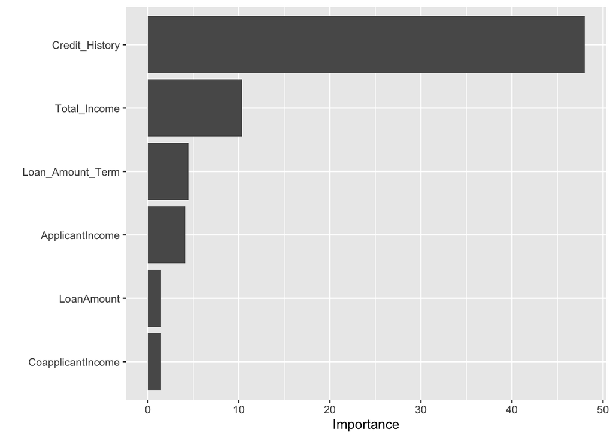

```r
final_tree %>%
  pull_workflow_fit() %>%
  vip::vip()
```

Credit History is by far our most importable variable for predicting loan status.

Lastly, we test our model and collect our metrics.

```r
final_fit <-
  final_wf %>%
  last_fit(split = loan_split, metrics = metric_set( accuracy, kap, roc_auc, sens, spec))

final_fit %>%
  collect_metrics()
```

```
## # A tibble: 5 x 4
##   .metric  .estimator .estimate .config
##   <chr>    <chr>          <dbl> <chr>
## 1 accuracy binary         0.747 Preprocessor1_Model1
## 2 kap      binary         0.362 Preprocessor1_Model1
## 3 sens     binary         0.419 Preprocessor1_Model1
## 4 spec     binary         0.906 Preprocessor1_Model1
## 5 roc_auc  binary         0.676 Preprocessor1_Model1
```

```r
final_fit %>%
  collect_predictions() %>%
  conf_mat(Loan_Status, .pred_class)
```

```
##           Truth
## Prediction  N  Y
##          N 13  6
##          Y 18 58
```